[figure not shown]

WI-420

Front Wiring Harness

WIRING SYSTEM

61.Front Wiring Harness

A: LOCATION

1. ENGINE TYPE FA

Connector Connecting to

No. Pole Color Area No. Description

F1 4 GR C-1 F6

Front wiring harness

F4 4 GR D-3 F21

F5 2 B B-1 Horn

F6 4 GR C-1 F1 Bumper light cord RH

F10 2 GR B-1 Front turn signal light RH

F12 2 B B-1 Daytime running light resistor

F13 2 GR D-4 Front turn signal light LH

F14 2 GR B-1 Front fog light RH

F15 2 GR D-4 Front fog light LH

F16 2 C-2 Sub fan motor

F17 2 C-3 Main fan motor

F21 4 GR D-3 F4 Bumper light cord LH

F24 1 B B-3 Magnet clutch

F25 1 B-3 Generator terminal B

F26 3 B-3 Generator

F27 26 B-5 Relay holder

F35 12 L B-5

M/BF36 7 B-5

F37 20 B-5

F47 2 B C-2 Horn

F78 2 B C-3 Ambient sensor

F108 18 GR B-4 B361

Through joint connector

F109 24 B-4 B360

F125 12 GR C-3 Front combination light LH

F126 12 GR B-2 Front combination light RH

F134 2 GR B-2 Vacuum pump

: White or natural color

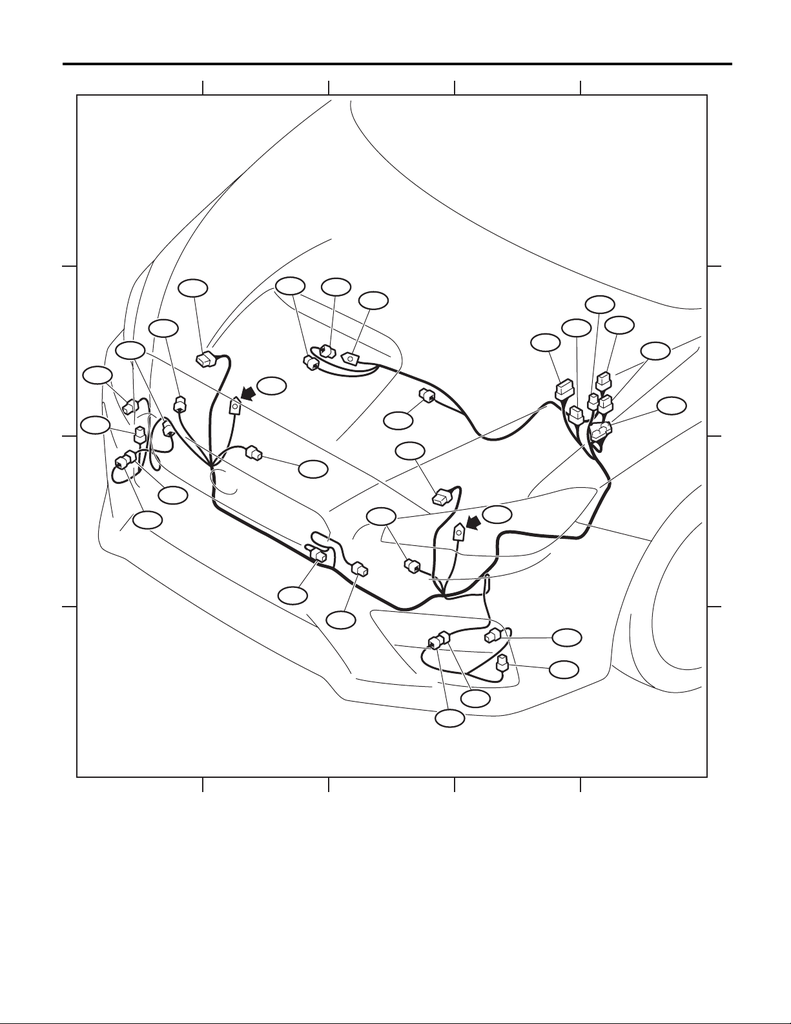

WI-421

Front Wiring Harness

WIRING SYSTEM

WI-44610

12345

12345

A

B

C

D

A

B

C

D

F26

F25

F134

F24

F5

F12

F14

F10

F6

F1

GB-1

F126

F16

F21

F4

F13

F15

GB-2

F17

F125

F78

F47

F37

F36

F35

F27

F108

F109

[figure not shown]

WI-422

Front Wiring Harness

WIRING SYSTEM

2. ENGINE TYPE EJ

Connector Connecting to

No. Pole Color Area No. Description

F1 4 GR C-1 F6

Front wiring harness

F4 4 GR D-3 F21

F5 2 B B-1 Horn

F6 4 GR C-1 F1 Front wiring harness

F9 16 B-4 Relay holder

F10 2 GR B-1 Front turn signal light RH

F11 2 B-4 Secondary air pump

F12 2 B B-1 Daytime running light resistor

F13 2 GR D-4 Front turn signal light LH

F14 2 GR B-1 Front fog light RH

F15 2 GR D-4 Front fog light LH

F16 2 C-2 Sub fan motor

F17 2 C-3 Main fan motor

F21 4 GR D-3 F4 Front wiring harness

F24 1 B B-3 Magnet clutch

F25 1 B-3 Generator terminal B

F26 3 B-3 Generator

F27 26 B-5 Relay holder

F35 12 L B-5

M/BF36 7 B-5

F37 20 B-5

F47 2 B C-2 Horn

F70 2 C-4 M/B

F78 2 B C-3 Ambient sensor

F108 18 GR B-4 B361

Through joint connector

F109 24 B-4 B360

F125 12 GR C-3 Front combination light LH

F126 12 GR B-2 Front combination light RH

: White or natural color

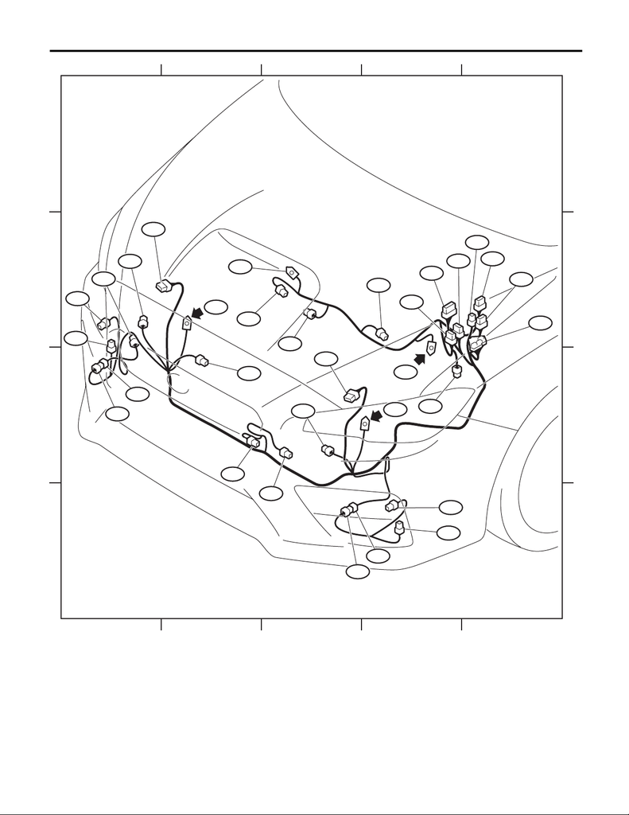

WI-423

Front Wiring Harness

WIRING SYSTEM

WI-44611

12345

12345

A

B

C

D

A

B

C

D

F11

GB-1

GB-2

GP

F24

F26

F25

F37

F36

F108

F109

F5

F12

F126

F14

F10

F6

F16

F1

F21

F4

F13

F15

F35

F27

F70

F9

F78

F17

F125

F47